# Comparing Cut Scores for the Updated Vocabulary Levels Test

Author

Wanying Lu

Published

November 24, 2026

## Introduction

Vocabulary levels tests estimate how well learners know the words at different frequency levels. The updated Vocabulary Levels Test (uVLT) (Webb et al., 2017) measures receptive vocabulary knowledge at five frequency levels, 1000, 2000, 3000, 4000, and 5000, with 30 items at each level. The test uses a cluster matching format. In each cluster the learner matches three definitions to three of six words, so the three remaining words act as distractors. Figure 1 shows one cluster.

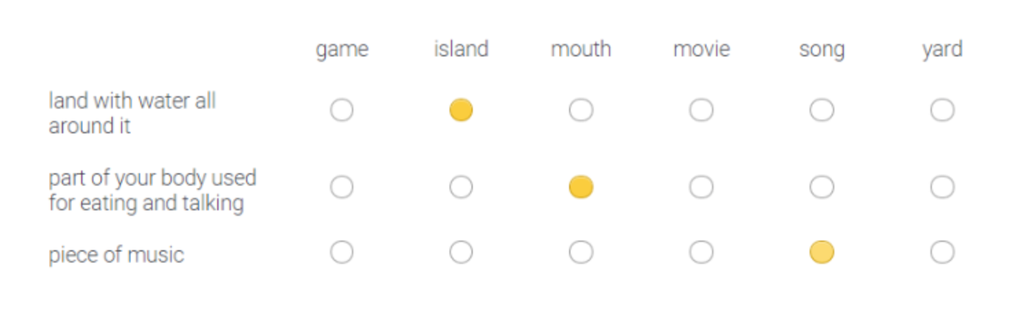

Figure 1: One cluster of uVLT items. The learner matches each definition on the left to one of the six words along the top.

These levels are not equally useful to a learner. The first 1000 word families cover about 78 to 81% of the running words in written English, the second 1000 adds a further 8 to 9%, the third adds 3 to 5%, and the fourth and fifth together add about 3% (Nation, 2006). Knowledge of the 1000 level therefore carries more weight for comprehension than knowledge of the 5000 level, which is one reason the high-frequency levels are treated as a priority in teaching.

The uVLT is used diagnostically. A teacher or learner reads the test results across levels and decides which frequency level to study next. This use depends on a cut score: a learner who reaches the cut score at a level is treated as knowing that level well enough to go on, and a learner who does not reach it is advised to keep studying that level.

The literature offers mainly two recommendations. Webb et al. (2017) set the cut score at 29/30 for the 1000, 2000, and 3000 levels and at 24/30 for the 4000 and 5000 levels. Schmitt et al. (2001) recommend 26/30 at every level. The two therefore disagree about learners who score 26 to 28 at a high-frequency level.

The choice between the two recommendations has consequences for learners. A stricter cut score may keep learners at the current level when they already know enough to benefit from focusing on the next one. A more lenient cut score may let learners go on to the next level before their knowledge of high-frequency words, words that provide more coverage and are therefore more important, is secure. However, to our knowledge, neither recommendation has been evaluated empirically.

Each recommendation is a learning target: it states how well a learner should know a level before going on. That is a claim about the level the cut score is applied to. It is also a claim about the next level. A learner who meets the cut score will be studying there, and a learner who does not is held at the current level on the grounds that the next one would be premature. The present study examines this second claim in uVLT scores from 6,636 Chinese learners of English, all of whom completed all five frequency levels. We estimate what reaching each cut score indicates about performance at the next level, and what scoring below it indicates.

We expected learners who meet 29/30 to perform better at the next level than learners who meet 26/30 but not 29/30, because scores at adjacent frequency levels draw on a common vocabulary ability. The open question is the size of that difference. If it falls within the measurement error of the test, a teacher has little reason to prefer one cut score over the other. If it is larger, the choice between them matters in practice. We also had no basis for expecting the difference to be the same at all three transitions, so we estimated it separately at each one. We ask one research question:

- What does meeting each of the two recommended cut scores at the 1000, 2000, and 3000 levels indicate about a learner’s performance at the next frequency level, after accounting for education?

## Methods

### Data source and permissions

We analysed uVLT responses from 6,636 Chinese learners of English, and the unit of observation is one set of responses from a learner. The data were provided by Dr. Stuart Webb, the test developer, who permitted the use for this project. Under this agreement the participant-level data are not published. The public repository contains the analysis code and the rendered report, and the data file is excluded from the repository by its ignore list. The test was administered online, and learners chose to take part. The sample included 3,790 high school graduates, 704 learners who had not completed high school, and 2,142 university graduates. No scores were missing.

### Measure

The uVLT contains five frequency levels with 30 items each, presented in a cluster matching format, and the score at each level is the number of items answered correctly, from 0 to 30. Mean scores were highest at the 1000 level and lower at each successive level (Table 2).

### Transitions and cut score groups

Both recommendations apply a cut score at every transition from one frequency level to the next, so we treated each transition as a separate analysis. At the 1000, 2000, and 3000 levels the two recommended cut scores are 26/30 and 29/30. These two numbers divide learners into three groups at each level:

- **Below 26.** Both recommendations advise the learner to keep studying this level.
- **26 to 28.** Schmitt et al. advise the learner to go on to the next level. Webb et al. advise more study at this level.
- **29 or 30.** Both recommendations advise the learner to go on to the next level.

We took the group at one level as the predictor and the score at the next level as the outcome. We label each transition by the two levels it joins, so at the 1000 to 2000 transition learners are grouped by their 1000 score and the outcome is their 2000 score. The research question concerns the three transitions this produces: 1000 to 2000, 2000 to 3000, and 3000 to 4000. We modelled the number of items answered correctly out of 30 at the next level, which expresses the difference between the groups in items.

### Analytic strategy

We fitted a generalised linear model with a logit link in glmmTMB (Brooks et al., 2017) at each transition, with education as a covariate and with the group between the two cut scores as the reference group.

We carried out the full model-building sequence at all three transitions. The sequence had three steps. First, we compared a binomial model with a beta-binomial model, which adds a dispersion parameter. Second, we compared four nested beta-binomial models with likelihood-ratio tests, AIC, and BIC: education alone; education plus an indicator for reaching 26/30; education plus indicators for both cut scores; and a model allowing the two effects to differ by education. We entered the two cut scores one at a time because the question is what 29/30 indicates beyond 26/30, and a sequential test isolates that increment. Third, we checked the residuals with DHARMa, and we report the numerical checks at all three transitions and the residual plots at one. We decided to carry one specification across the three transitions, because the research question compares what each cut score indicates at successive levels and a common specification keeps those estimates comparable. Finally, we report the percentage of learners in each group who reach every threshold from 24 to 30 items at the next level, with 95% confidence intervals.

## Results

We first describe the sample and the score distributions. We then set out the model-building sequence and the residual checks, and report the estimates that answer the research question. The final subsection shows what proportion of each group reached every score from 24 to 30 items at the next level.

### Descriptive statistics

Table 1 describes the sample. Table 2 shows the scores at all five frequency levels, and mean scores declined from 1000 to 5000. Table 3 gives the number of learners in each group at each transition. The group between the two cut scores, whom the two recommendations treat differently, contains 1,060 learners at the 1000 to 2000 transition, 1,880 at the 2000 to 3000 transition, and 1,519 at the 3000 to 4000 transition.

The three transitions differ in where this group sits in the distribution. At the 1000 level, 5,100 learners scored 29 or 30 and only 476 scored below 26. At the 3000 level, 3,787 learners scored below 26 and only 1,330 scored 29 or 30. A score of 26 to 28 therefore places a learner near the bottom of the distribution at 1000 and above the middle at 3000.

Table 1: Sample characteristics

| Education | n | % |
| --- | --- | --- |
| Below High School | 704 | 10.6% |
| High School Graduate | 3790 | 57.1% |
| University Graduate | 2142 | 32.3% |

N = 6,636

Table 2: Scores at the five frequency levels (items correct out of 30)

| Level | M | SD | Median | Min | Max |
| --- | --- | --- | --- | --- | --- |
| 1000 | 28.67 | 3.02 | 30 | 3 | 30 |
| 2000 | 25.68 | 5.53 | 28 | 1 | 30 |
| 3000 | 22.38 | 6.90 | 24 | 1 | 30 |
| 4000 | 19.19 | 7.49 | 20 | 1 | 30 |
| 5000 | 16.02 | 8.18 | 16 | 0 | 30 |

N = 6,636.

Table 3: Number of learners in each cut score group, by the score at the first level of each transition

| Score at level | Below 26 | 26 to 28 | 29 or 30 |
| --- | --- | --- | --- |
| 1000 | 476 | 1060 | 5100 |
| 2000 | 2055 | 1880 | 2701 |
| 3000 | 3787 | 1519 | 1330 |

Every learner appears once in each row block. N = 6,636 at each transition.

### Model comparison and selection

We made two modelling decisions at each transition: which distribution family to use, and which predictors to keep.

First, the binomial model was overdispersed at every transition. The Pearson dispersion ratio ranged from 3.87 to 4.49, where 1 is the value the model expects, and refitting with a beta-binomial distribution lowered AIC by 9,394 to 14,256 (Table 4). We therefore used the beta-binomial family at all three transitions.

Table 4: Binomial compared with beta-binomial at each transition

| Grouped at | Scored at | Binomial dispersion ratio | AIC binomial | AIC beta-binomial | AIC reduction |
| --- | --- | --- | --- | --- | --- |
| 1000 | 2000 | 3.89 | 39,716 | 30,322 | 9,394 |
| 2000 | 3000 | 3.87 | 46,399 | 35,663 | 10,736 |
| 3000 | 4000 | 4.49 | 53,294 | 39,038 | 14,256 |

Both models contain the cut score group and education. A dispersion ratio above 1 means the data vary more than the binomial model allows.

Second, Table 5 shows the nested comparison at each transition. We entered the two cut scores one at a time, so that the test of 29/30 measures what it adds beyond 26/30. Reaching 26/30 improved fit over education alone at every transition, with chi-square values of 2062.27 to 3685.07 on 1 degree of freedom, all p < .001. Reaching 29/30 improved fit again at every transition, with chi-square values of 422.50 to 1201.25 on 1 degree of freedom, all p < .001. Allowing the two effects to differ by education improved fit at 3 of the three transitions, and BIC was lower for the interaction model at 3 of them.

Because BIC penalises complexity heavily, this suggests that the extra parameters earn their place. We therefore report predicted scores from the interaction model, and we also report the single odds ratio from the model without the interaction, because it summarises the average difference across education levels in one number. The order of entry determines how the combined effect is divided between the two cut scores, and we chose the order that matches the question, so that 29/30 is judged by what it adds to 26/30. The same specification is used at all three transitions, which keeps the estimates comparable.

Table 5: Nested model comparison at each transition (beta-binomial models)

| Model | AIC | BIC | Log-likelihood | Deviance | Residual df | Nested chi-square | Nested df | Nested p |
| --- | --- | --- | --- | --- | --- | --- | --- | --- |
| Grouped at 1000, scored at 2000 |  |  |  |  |  |  |  |  |
| m0: education | 33581.9 | 33609.1 | -16786.9 | 33573.9 | 6632 |  |  |  |
| m1a: + 26/30 | 31521.6 | 31555.6 | -15755.8 | 31511.6 | 6631 | 2062.3 | 1 | < .001 |
| m1b: + 29/30 | 30322.3 | 30363.1 | -15155.2 | 30310.3 | 6630 | 1201.3 | 1 | < .001 |
| m2: + rules x education | 30282.3 | 30350.3 | -15131.1 | 30262.3 | 6626 | 48.0 | 4 | < .001 |
| Grouped at 2000, scored at 3000 |  |  |  |  |  |  |  |  |
| m0: education | 39808.7 | 39835.9 | -19900.4 | 39800.7 | 6632 |  |  |  |
| m1a: + 26/30 | 36417.3 | 36451.3 | -18203.6 | 36407.3 | 6631 | 3393.4 | 1 | < .001 |
| m1b: + 29/30 | 35663.0 | 35703.8 | -17825.5 | 35651.0 | 6630 | 756.3 | 1 | < .001 |
| m2: + rules x education | 35555.6 | 35623.6 | -17767.8 | 35535.6 | 6626 | 115.4 | 4 | < .001 |
| Grouped at 3000, scored at 4000 |  |  |  |  |  |  |  |  |
| m0: education | 43141.8 | 43169.0 | -21566.9 | 43133.8 | 6632 |  |  |  |
| m1a: + 26/30 | 39458.7 | 39492.7 | -19724.4 | 39448.7 | 6631 | 3685.1 | 1 | < .001 |
| m1b: + 29/30 | 39038.2 | 39079.0 | -19513.1 | 39026.2 | 6630 | 422.5 | 1 | < .001 |
| m2: + rules x education | 38951.3 | 39019.3 | -19465.7 | 38931.3 | 6626 | 94.9 | 4 | < .001 |

Each likelihood-ratio test compares a model with the model in the row above.

### Model diagnostics

Table 6 compares the residual checks for the two families at all three transitions. Under the binomial model the dispersion ratio ranged from 1.51 to 1.69; under the selected beta-binomial model it ranged from 1.03 to 1.05. Outliers made up 0.26 to 0.35 percent of learners under the selected models. Several tests remained significant. With more than 6000 learners these tests detect small deviations, so we read them alongside the plots. Figure 2 and Figure 3 show the plots for the 3000 to 4000 transition; Table 6 reports the numerical checks for all three.

Table 6: Residual checks at each transition (DHARMa)

| Model | Dispersion ratio | Dispersion p | KS p | Outliers (%) |
| --- | --- | --- | --- | --- |
| Grouped at 1000, scored at 2000 |  |  |  |  |
| Binomial | 1.51 | < .001 | < .001 | 7.01 |
| Beta-binomial | 1.05 | .012 | .095 | 0.35 |
| Grouped at 2000, scored at 3000 |  |  |  |  |
| Binomial | 1.51 | < .001 | < .001 | 9.57 |
| Beta-binomial | 1.03 | .016 | .074 | 0.32 |
| Grouped at 3000, scored at 4000 |  |  |  |  |
| Binomial | 1.69 | < .001 | < .001 | 13.56 |
| Beta-binomial | 1.03 | .048 | .268 | 0.26 |

Both models contain the cut score group and education. KS = Kolmogorov-Smirnov test of uniform residuals.

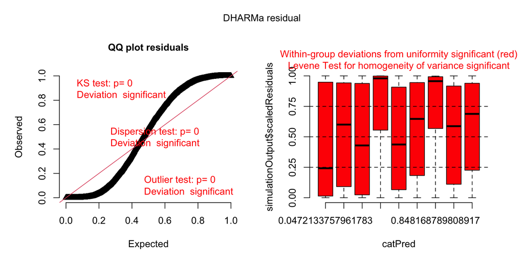

Figure 2: DHARMa residuals for the binomial model at the 3000 to 4000 transition

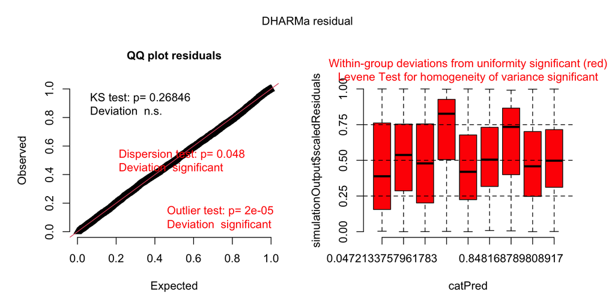

Figure 3: DHARMa residuals for the selected beta-binomial model at the 3000 to 4000 transition

### The difference between the two groups at the next level

At every high-frequency transition, learners who scored 29 or 30 answered more items correctly at the next level than learners who scored 26 to 28, after accounting for education (Table 7). The odds ratio for answering a given item correctly at the next level was 3.30 [3.11, 3.50] at the 1000 to 2000 transition, 2.26 [2.13, 2.39] at the 2000 to 3000 transition, and 2.17 [2.01, 2.34] at the 3000 to 4000 transition.

Learners who scored below 26 at the current level performed worse at the next level than the reference group. The odds ratio was 0.25 to 0.31 across the three transitions, so learners who scored 26 to 28 held roughly 3.3 to 4.0 times the odds of learners who scored below 26 (Table 7). On the items scale this group averaged 8.6 to 10.0 fewer items at the next level than the reference group. At all three transitions the distance between the below-26 group and the reference group was larger than the distance between the reference group and the group that scored 29 or 30. The below-26 group covers scores from 0 to 25, a wider range than either of the other two groups, which may account for part of this difference.

Table 7: Next-level score of each group compared with learners scoring 26 to 28, at each transition

| Group at the current level | OR [95% CI] | p |
| --- | --- | --- |
| Grouped at 1000, scored at 2000 |  |  |
| Below 26 | 0.25 [0.23, 0.27] | < .001 |
| 29 or 30 | 3.30 [3.11, 3.50] | < .001 |
| Grouped at 2000, scored at 3000 |  |  |
| Below 26 | 0.31 [0.29, 0.32] | < .001 |
| 29 or 30 | 2.26 [2.13, 2.39] | < .001 |
| Grouped at 3000, scored at 4000 |  |  |
| Below 26 | 0.28 [0.27, 0.30] | < .001 |
| 29 or 30 | 2.17 [2.01, 2.34] | < .001 |

The reference group is learners who score 26 to 28, whom the two recommendations treat differently. Education is held constant. An odds ratio above 1 means the group scored higher at the next level than the reference group, and an odds ratio below 1 means it scored lower.

Figure 4 shows the predicted score for each group, and Table 8 translates the difference into items and into units of measurement error. Learners who scored 29 or 30 were predicted to answer 2.2 to 6.0 more items at the next level than learners who scored 26 to 28, depending on the transition and the education level. To judge whether a difference of this size matters in practice, we compared it with the binomial standard error of measurement at the predicted score of the group that scored 26 to 28. The differences ranged from 1.08 to 2.33 SEM, and 9 of 9 comparisons reached at least one SEM. A difference smaller than one SEM falls within the variation expected when the same learner takes the test again. The difference was larger at the 1000 to 2000 transition than at the other two, which were close to each other.

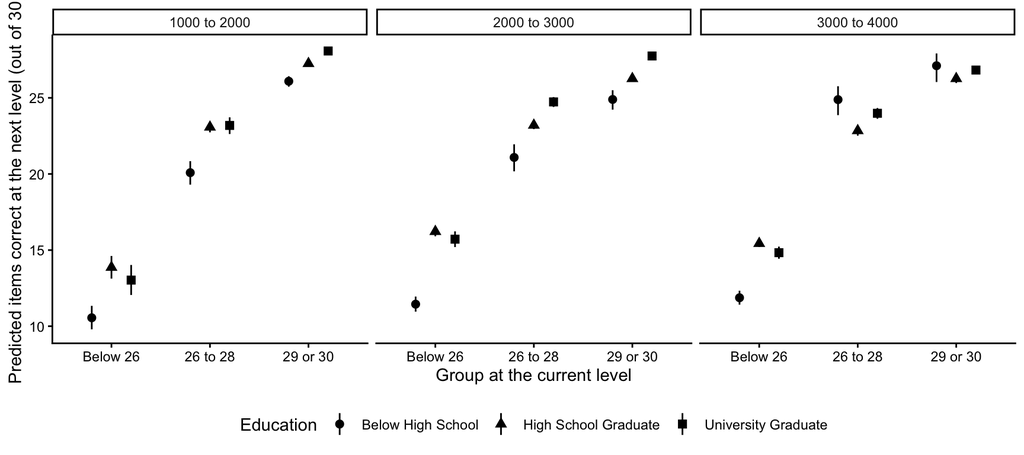

Figure 4: Predicted items correct at the next frequency level by cut score group and education level, with 95% confidence intervals

Table 8: Difference in next-level score between learners scoring 29 or 30 and learners scoring 26 to 28, in items and in units of measurement error

| Education | Difference (items) | SEM | Difference (SEM) |
| --- | --- | --- | --- |
| Grouped at 1000, scored at 2000 |  |  |  |
| Below High School | 6.0 | 2.58 | 2.33 |
| High School Graduate | 4.2 | 2.31 | 1.81 |
| University Graduate | 4.9 | 2.29 | 2.13 |
| Grouped at 2000, scored at 3000 |  |  |  |
| Below High School | 3.8 | 2.50 | 1.52 |
| High School Graduate | 3.1 | 2.29 | 1.34 |
| University Graduate | 3.0 | 2.08 | 1.45 |
| Grouped at 3000, scored at 4000 |  |  |  |
| Below High School | 2.2 | 2.06 | 1.08 |
| High School Graduate | 3.4 | 2.33 | 1.47 |
| University Graduate | 2.8 | 2.19 | 1.30 |

Differences come from the model allowing the two cut score effects to differ by education; the predicted scores they are based on are shown in the figure above. SEM is the binomial standard error of measurement at the predicted score of the group that scored 26 to 28.

### Proportion of each group reaching each score from 24 to 30

Figure 5 and Table 9 show the proportion of each group that scores at or above every threshold from 24 to 30 items at the next level. The three high-frequency transitions produced similar curves. Among learners who scored 26 to 28, the proportion scoring at least 24 items at the next level ranged from 48.9% to 57.3%, the proportion scoring at least 26 items ranged from 35.6% to 38.6%, and the proportion scoring at least 29 items ranged from 9.5% to 13.0%. Among learners who scored 29 or 30, the proportion scoring at least 26 items at the next level was 82.1%, 74.6%, and 74.4% at the three transitions.

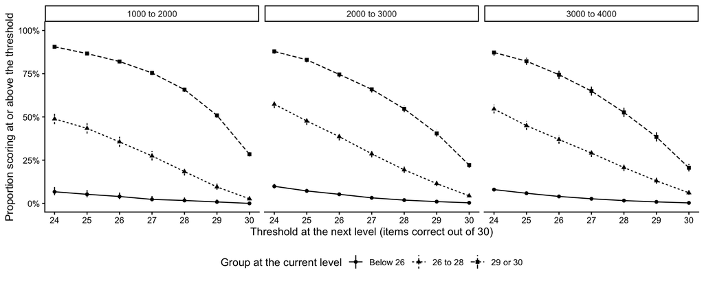

Figure 5: Proportion of each cut score group scoring at or above every threshold from 24 to 30 items at the next frequency level, with 95% confidence intervals. The intervals are narrow because the groups are large.

Table 9: Proportion of learners scoring at or above each threshold at the next frequency level

| Group at the current level | Items correct at the next level ≥ 24 | Items correct at the next level ≥ 25 | Items correct at the next level ≥ 26 | Items correct at the next level ≥ 27 | Items correct at the next level ≥ 28 | Items correct at the next level ≥ 29 | Items correct at the next level ≥ 30 |
| --- | --- | --- | --- | --- | --- | --- | --- |
| Grouped at 1000, scored at 2000 |  |  |  |  |  |  |  |
| Below 26 | 6.7% | 5.3% | 4.0% | 2.3% | 1.7% | 0.8% | 0.0% |
| 26 to 28 | 48.9% | 43.4% | 35.6% | 27.5% | 18.4% | 9.5% | 2.6% |
| 29 or 30 | 90.6% | 86.7% | 82.1% | 75.5% | 65.8% | 50.9% | 28.4% |
| Grouped at 2000, scored at 3000 |  |  |  |  |  |  |  |
| Below 26 | 9.9% | 7.2% | 5.3% | 3.2% | 1.9% | 1.0% | 0.3% |
| 26 to 28 | 57.3% | 47.7% | 38.6% | 28.7% | 19.4% | 11.4% | 4.4% |
| 29 or 30 | 87.9% | 83.0% | 74.6% | 66.0% | 54.7% | 40.5% | 22.1% |
| Grouped at 3000, scored at 4000 |  |  |  |  |  |  |  |
| Below 26 | 8.0% | 5.9% | 4.0% | 2.7% | 1.6% | 0.9% | 0.3% |
| 26 to 28 | 54.6% | 45.0% | 36.9% | 29.1% | 20.7% | 13.0% | 6.1% |
| 29 or 30 | 87.3% | 82.3% | 74.4% | 65.0% | 52.6% | 38.4% | 20.6% |

Values are cumulative: each column gives the percentage of learners in that group who scored at or above that number of items, so a row does not sum to 100%. The 95% confidence intervals are narrow because the groups are large: the widest has a half-width of 3.1 percentage points. They are plotted in the figure above.

## Discussion

We asked what meeting each of the two recommended cut scores indicates about performance at the next frequency level, and we analysed each transition from one level to the next separately. First, at all three high-frequency transitions, learners who met 29/30 answered more items correctly at the next level than learners who met 26/30 but not 29/30, and the confidence intervals were narrow. On the scale the model estimates, the odds of answering a given item correctly at the next level were 2.17 to 3.30 times higher for learners who met 29/30, and the confidence interval excluded 1 at every transition. The difference was 2.2 to 6.0 items out of 30, and it exceeded one standard error of measurement in 9 of 9 comparisons. Meeting 29/30 therefore indicates a different expected performance at the next level than meeting 26/30 alone, and the difference is larger than the measurement error of the test itself.

Learners who do not reach 26 sit further from the middle group than learners who reach 29 or 30 do. Both recommendations advise these learners to keep studying the current level, and these data are consistent with that advice. This group averaged 8.6 to 10.0 fewer items at the next level than learners who scored 26 to 28, and fewer than one in ten of them reached 24 items there (Table 9). The 26 boundary therefore separates more next-level performance than the 29 boundary does, although the below-26 group spans scores from 0 to 25 while the other two groups span three points and two, so the boundaries are not directly comparable.

Second, the size of the difference was not constant across the three transitions. It was largest at the 1000 to 2000 transition and close to equal at the other two. One explanation is that 26/30 and 29/30 do not divide equally different learners at each level, because the distribution of scores shifts downward as word frequency decreases. At the 1000 level the test was close to its ceiling (median = 30/30), and 57.7% of learners answered every item correctly. Only 7.2% of learners scored below 26 at that level, compared with 31.0% at the 2000 level and 57.1% at the 3000 level. A learner who scored 26 to 28 at the 1000 level therefore fell in the lowest 23.1% of the sample, while the same score at the 3000 level fell above 57.1% of the sample. The group that 29/30 is compared against is an unusually weak group at the 1000 level and an above-average group at the 3000 level. A learner’s score at one level and the same learner’s score at the next both reflect vocabulary knowledge, so a cut score that divides a weak minority from the majority may separate more of that knowledge than a cut score that divides two adjacent groups in the middle of the distribution. Thus the difference may be largest at the 1000 to 2000 transition because 29/30 there separates learners who missed two or more items among the 1000 most frequent words from learners who missed at most one.

This explanation accounts for only part of the pattern. If the position of the cut score in the distribution were the whole account, the difference would shrink at each step from 1000 to 3000, because the proportion of learners scoring below 26 rises at each level. The difference was instead close to equal at the 2000 to 3000 and 3000 to 4000 transitions. We cannot determine from these data what else contributes.

This matters for how cut scores are set. A single cut score applied at every level does not hold learners to a constant standard: 26/30 admits 92.8% of learners at the 1000 level but only 42.9% at the 3000 level, and 29/30 admits 76.9% and 20.0%. Neither recommendation varies its cut score across the three high-frequency levels, so neither avoids this. A cut score that varies by level may address it more directly.

Third, what 29/30 costs depends on the score taken to indicate sufficient knowledge of the next level. By cost we mean the proportion of learners it holds back who would have met that score. Among learners who scored 26 to 28, about half scored at least 24 items at the next level, about a third scored at least 26, and about one in ten scored at least 29. These proportions were similar at all three transitions (Table 9). The cost of 29/30 therefore moves with the score chosen. If that score is 24, about half of the learners it keeps at the current level would have met it. If it is 26, about a third would. If it is 29, about one in ten would.

For teachers and test users, these results describe what each cut score tells them about a learner who has just finished a level. A learner who meets 29/30 is expected to answer 2.2 to 6.0 more items at the next level than a learner who scores 26 to 28, and about three quarters of these learners reach 26 items there (Table 9). A learner who meets 26/30 without meeting 29/30 carries a weaker signal, because about a third of this group reaches the same score at the next level.

There are several limitations in these conclusions. First, all evidence comes from the same test. The data contain no measure of vocabulary knowledge that is independent of the uVLT, so we cannot judge whether either cut score identifies mastery of the level it was applied to. Second, the sample was cross-sectional and self-selected, and it included Chinese learners only. Future studies could test the cut scores against an external criterion such as reading comprehension, examine classification consistency with item-level data, and follow learners over time to see how those who are advised to keep studying a level progress.

In this sample, learners who scored below 26 rarely reached even 24 items at the next level. Learners who scored 26 to 28 were divided: about half reached 24 and about a third reached 26. Learners who scored 29 or 30 reached 26 items about three times in four. The three scores therefore carry three different signals, and the difference between the two groups the recommendations disagree about was larger than the measurement error of the test. The choice between 26/30 and 29/30 is consequential for the learners it separates.

## References

Brooks, M. E., Kristensen, K., van Benthem, K. J., Magnusson, A., Berg, C. W., Nielsen, A., Skaug, H. J., Mächler, M., & Bolker, B. M. (2017). glmmTMB balances speed and flexibility among packages for zero-inflated generalized linear mixed modeling. *The R Journal, 9*(2), 378–400. https://doi.org/10.32614/RJ-2017-066

Nation, I. S. P. (2006). How large a vocabulary is needed for reading and listening? *The Canadian Modern Language Review, 63*(1), 59–82. https://doi.org/10.3138/cmlr.63.1.59

Schmitt, N., Schmitt, D., & Clapham, C. (2001). Developing and exploring the behaviour of two new versions of the Vocabulary Levels Test. *Language Testing, 18*(1), 55–88. https://doi.org/10.1177/026553220101800103

Webb, S., Sasao, Y., & Ballance, O. (2017). The updated Vocabulary Levels Test: Developing and validating two new forms of the VLT. *ITL: International Journal of Applied Linguistics, 168*(1), 33–69. https://doi.org/10.1075/itl.168.1.02web